# R/RStudio (Part 1). Data wrangling, visualization & statistial analysis (CSB chap 9 + iris)

### 9.6.3 Plotting Frequency Distribution of One Continuous Variable

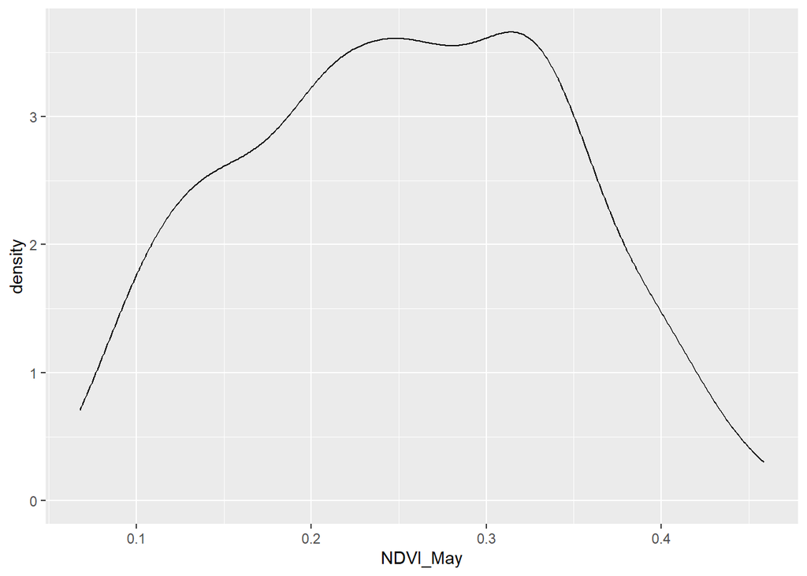

```r
#plot a histogram
ggplot(data = ndvi) +
  aes(x = NDVI_May) +
  geom_histogram() #each bar represents the number pf data points (count) that fall into a certain data range (bin)
# nested or "unrolled"
# these three commands produce the same graph:
ggplot(data = ndvi) +
  aes(x = NDVI_May) +
  geom_histogram()
ggplot(data = ndvi, aes(x = NDVI_May)) +
  geom_histogram()
ggplot(data = ndvi) +
  geom_histogram(aes(x = NDVI_May))
#interpolate the histogram and produce a density plot
ggplot(data = ndvi) + aes(x = NDVI_May) + geom_density()
```

[output not shown]

### 9.6.4 Box Plots and Violin Plots

Box plots and violin plots are excellent for providing information on the distribution of your data. A box plot marks the median (50th percentile) of the values as a line in the middle of a box enclosing half of your data (from the 25th to the 75th percentile). The lines extending from the box (whiskers) rep- resent 1.5 × the length of the box (or interquartile range, IQR). Data points falling beyond the whiskers are drawn separately as outliers.

Violin plots add information on the distribution of data (i.e., where a violin plot is wider, more data points cluster—you can think of a violin plot as the union of two mirrored density plots).

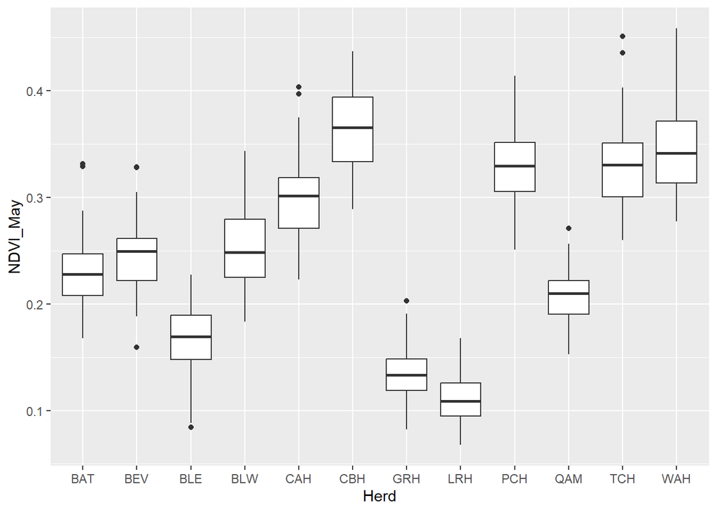

```r
pl <- ggplot(data = ndvi) + aes(x = Herd, y = NDVI_May)
pl + geom_boxplot()
```

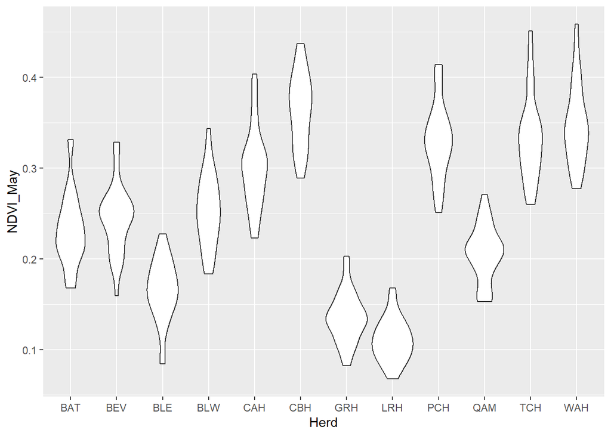

```r
pl + geom_violin()
```

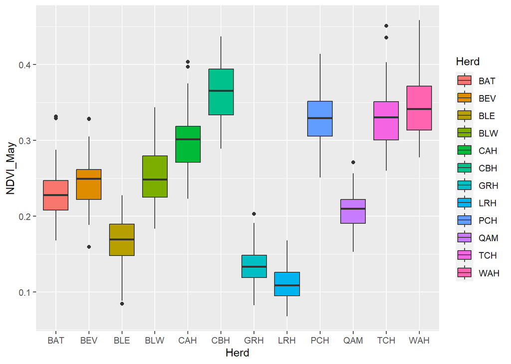

```r
pl + geom_boxplot() + aes(fill = Herd) # change the color for the boxes, set the aesthetic fill
```

### 9.6.5 Bar Plots

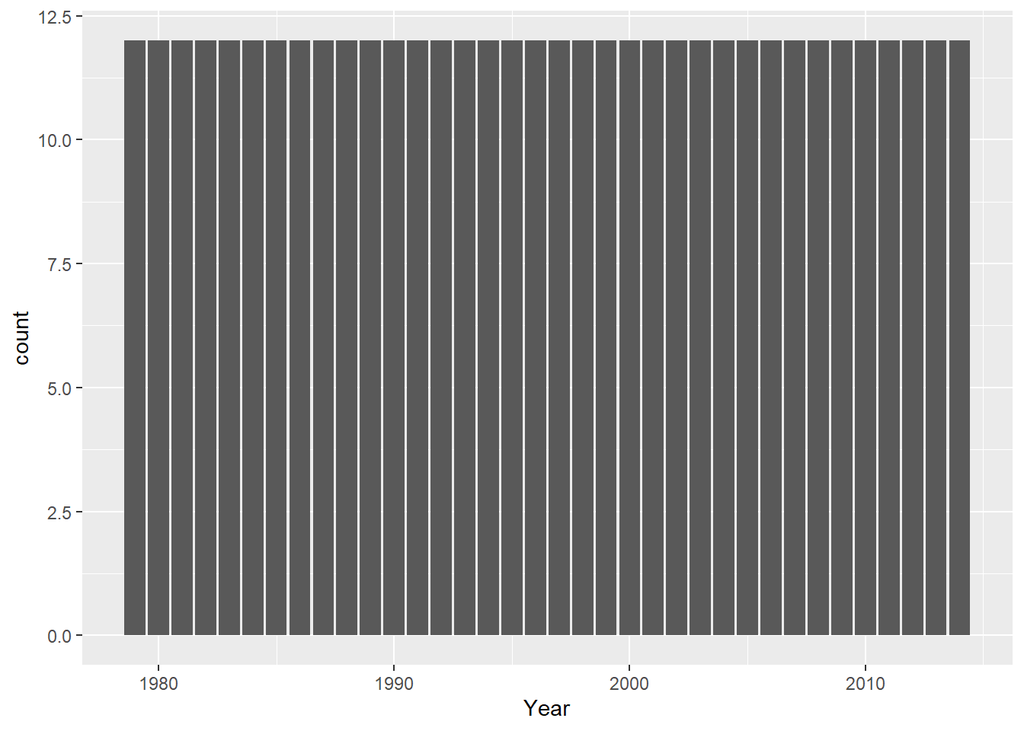

```r
ggplot(data = seaice %>% filter(Herd == "WAH")) +
  aes(x = Year) +
  geom_bar() # shows that we have 12 records per year for all the years between 1979 and 2014
```

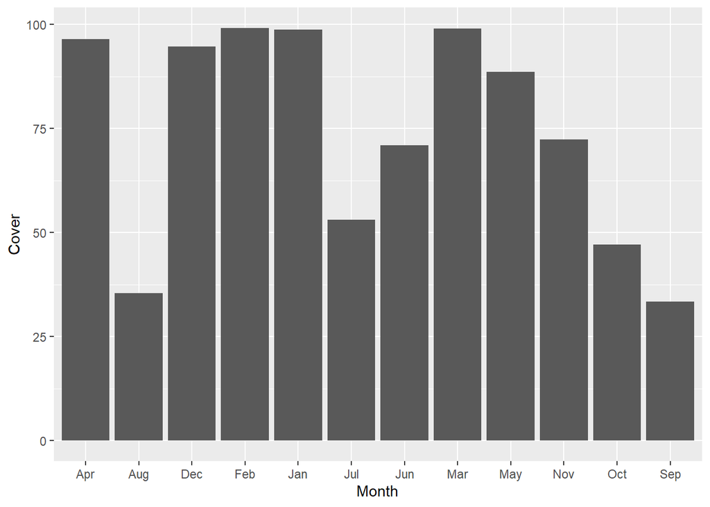

```r
# When we want the height of the bars to represent a value in a column (instead of a count), we can use geom_col
ggplot(data = seaice %>%
         filter(Herd == "WAH", Year == 1990)) +
  aes(x = Month, y = Cover) + geom_col()
```

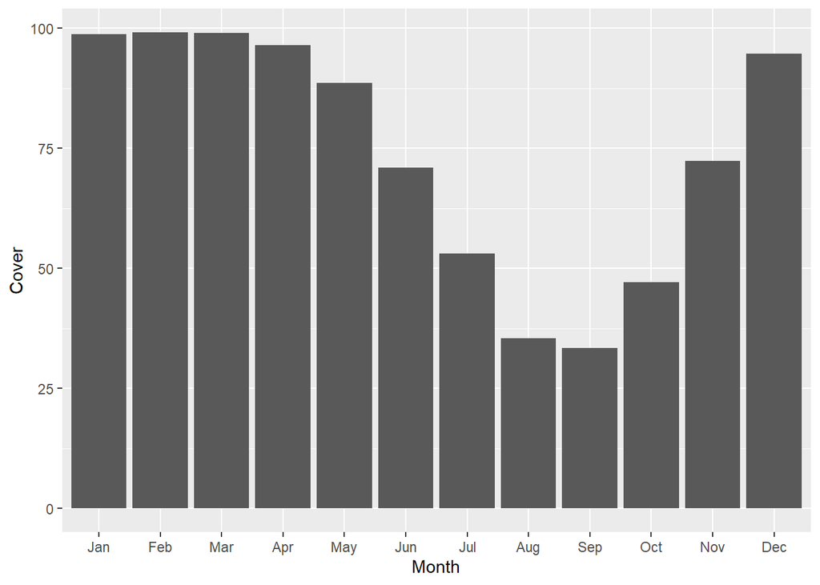

```r
seaice$Month <- factor(seaice$Month, month.abb)
ggplot(data = seaice %>%
         filter(Herd == "WAH", Year == 1990)) +
  aes(x = Month, y = Cover) + geom_col()
```